# 511-LM

Natalie Smith

2022-12-02

## Linear Regression

The goal of linear regression, in short, is to predict the value of a chosen response variable based on the value of another variable or variables, which are called “predictors”. The equations of multiple linear regression models, which consider multiple predictor variables, take the following form:

$Y = \beta_0 + \beta_1X_1 + \beta_2X_2 + ... + \beta_pX_p + \epsilon$, where $\epsilon$ represents the error present in the model.

## Research Question

1. Can the elements of a car’s design be used to predict its $CO_2$ output?
2. Which elements of a car’s design are best at predicting $CO_2$ output?

## Assumptions of Linear Regression

1. Individual observations are independent from each other
2. A linear relationship exists between the independent predictor variables $X_i$ and the dependent response variable $Y$
3. Homoscedasticity, or homogeneity of variance
4. The residuals of the model are normally distributed

In this section, we are going use multiple linear regression to determine which elements of a car’s design (predictor variables $X_1$,$X_2$, … , $X_n$) are good predictors of a car’s $CO_2$ emissions (response variable $Y$).

Since electric cars do not give off $CO_2$ emissions, I am going to start by reading in our cleaned non-electric, or fuel-based cars, dataset.

```r
setwd("..")
getwd()
```

```
## [1] "/Users/smithnatalie/ANLY511-Final-Project"
```

```r
nonelectric = read.csv("data/cardata_nonelectric_clean.csv")
```

```r
library(caret)
library(tidyverse)
library(car)
library(ISLR2)
library(leaps)
```

Before splitting into training and testing, I want to ensure the predictor of Model Year can be considered as categorical for the regression model by adding a categorical column with the same data to the dataset.

```r
dplyr::count(nonelectric, Model.Year, sort = TRUE)
```

```
##   Model.Year    n
## 1       2018 4607
## 2       2019 4559
## 3       2020 4298
## 4       2022 4191
## 5       2021 4083
```

```r
nonelectric$Model.Year.Cat = as.character(nonelectric$Model.Year)
```

Next, the data will be split into training and testing datasets with an 80/20 split.

```r
set.seed(101)

training.samples = nonelectric$CO2..g.mi. %>%
  createDataPartition(p = 0.8, list = FALSE)

training.data = nonelectric[training.samples,]
testing.data = nonelectric[-training.samples, ]
```

```r
dim(training.data)
```

```
## [1] 17392    39
```

```r
dim(testing.data)
```

```
## [1] 4346   39
```

```r
head(training.data)
```

```
##   X Model.Year Vehicle.Manufacturer.Name Veh.Mfr.Code Represented.Test.Veh.Make
## 1 1       2018              aston martin          ASX              Aston Martin
## 2 2       2018              aston martin          ASX              Aston Martin
## 3 3       2018              aston martin          ASX              Aston Martin
## 4 4       2018              aston martin          ASX              Aston Martin
## 5 5       2018              aston martin          ASX              Aston Martin
## 6 6       2018              aston martin          ASX              Aston Martin
##   Represented.Test.Veh.Model Test.Veh.Displacement..L. Vehicle.Type
## 1                       DB11                       5.2          Car
## 2                       DB11                       5.2          Car
## 3                    DB11 V8                       4.0          Car
## 4                    DB11 V8                       4.0          Car
## 5                   Rapide S                       6.0          Car
## 6                   Rapide S                       6.0          Car
##   Rated.Horsepower X..of.Cylinders.and.Rotors Tested.Transmission.Type.Code
```

[output cut: 69 more lines]

```r
head(testing.data)
```

```
##     X Model.Year Vehicle.Manufacturer.Name Veh.Mfr.Code
## 10 10       2018                   Bentley          BEX
## 26 26       2018                       BMW          BMX
## 29 29       2018                       BMW          BMX
## 30 30       2018                       BMW          BMX
## 49 49       2018                       BMW          BMX
## 51 51       2018                       BMW          BMX
##    Represented.Test.Veh.Make Represented.Test.Veh.Model
## 10                   BENTLEY             Continental GT
## 26                       BMW                 230i Coupe
## 29                       BMW                 230i Coupe
## 30                       BMW                 230i Coupe
## 49                       BMW                       320i
## 51                       BMW                       320i
##    Test.Veh.Displacement..L. Vehicle.Type Rated.Horsepower
```

[output cut: 76 more lines]

Next, it is important to check the data for any missing values before proceeding.

```r
colSums(is.na(training.data))
```

```
##                             X                    Model.Year
##                             0                             0
##     Vehicle.Manufacturer.Name                  Veh.Mfr.Code
##                             0                             0
##     Represented.Test.Veh.Make    Represented.Test.Veh.Model
##                             0                             0
##     Test.Veh.Displacement..L.                  Vehicle.Type
##                             0                             0
##              Rated.Horsepower    X..of.Cylinders.and.Rotors
##                             0                             0
## Tested.Transmission.Type.Code      Tested.Transmission.Type
##                             0                             0
##                   X..of.Gears          Transmission.Lockup.
##                             0                             0
##             Drive.System.Code      Drive.System.Description
##                             0                             0
## Equivalent.Test.Weight..lbs..                    Axle.Ratio
##                             0                             0
##                     N.V.Ratio    Test.Fuel.Type.Description
##                             0                             0
##                    THC..g.mi.                     CO..g.mi.
##                             0                             0
##                    CO2..g.mi.                    RND_ADJ_FE
##                             0                             0
##  DT.Inertia.Work.Ratio.Rating DT.Absolute.Speed.Change.Ratg
##                             0                             0
##      DT.Energy.Economy.Rating           Target.Coef.A..lbf.
##                             0                             0
##       Target.Coef.B..lbf.mph.    Target.Coef.C..lbf.mph..2.
##                             0                             0
##              Set.Coef.A..lbf.          Set.Coef.B..lbf.mph.
##                             0                             0
##       Set.Coef.C..lbf.mph..2.      Aftertreatment.Device.Cd
##                             0                           158
##    Aftertreatment.Device.Desc   Police...Emergency.Vehicle.
##                           158                             0
##           Averaging.Method.Cd          Averging.Method.Desc
##                             0                             0
##                Model.Year.Cat
##                             0
```

```r
colSums(is.na(testing.data))
```

```
##                             X                    Model.Year
##                             0                             0
##     Vehicle.Manufacturer.Name                  Veh.Mfr.Code
##                             0                             0
##     Represented.Test.Veh.Make    Represented.Test.Veh.Model
##                             0                             0
##     Test.Veh.Displacement..L.                  Vehicle.Type
##                             0                             0
##              Rated.Horsepower    X..of.Cylinders.and.Rotors
##                             0                             0
## Tested.Transmission.Type.Code      Tested.Transmission.Type
##                             0                             0
##                   X..of.Gears          Transmission.Lockup.
##                             0                             0
##             Drive.System.Code      Drive.System.Description
##                             0                             0
## Equivalent.Test.Weight..lbs..                    Axle.Ratio
##                             0                             0
##                     N.V.Ratio    Test.Fuel.Type.Description
##                             0                             0
##                    THC..g.mi.                     CO..g.mi.
##                             0                             0
##                    CO2..g.mi.                    RND_ADJ_FE
##                             0                             0
##  DT.Inertia.Work.Ratio.Rating DT.Absolute.Speed.Change.Ratg
##                             0                             0
##      DT.Energy.Economy.Rating           Target.Coef.A..lbf.
##                             0                             0
##       Target.Coef.B..lbf.mph.    Target.Coef.C..lbf.mph..2.
##                             0                             0
##              Set.Coef.A..lbf.          Set.Coef.B..lbf.mph.
##                             0                             0
##       Set.Coef.C..lbf.mph..2.      Aftertreatment.Device.Cd
##                             0                            35
##    Aftertreatment.Device.Desc   Police...Emergency.Vehicle.
##                            35                             0
##           Averaging.Method.Cd          Averging.Method.Desc
##                             0                             0
##                Model.Year.Cat
##                             0
```

Above, it can be seen that the Aftertreatment.Device.Cd and the Aftertreatment.Device.Desc have missing values. Because these columns may be significant in the model and because there are still many rows in the dataset, I will remove these rows from the original dataset and run the train/test split again.

```r
nonelectric = nonelectric %>% drop_na()
```

Now, the split will be done again before proceeding to the linear regression model.

```r
set.seed(101)

training.samples = nonelectric$CO2..g.mi. %>%
  createDataPartition(p = 0.8, list = FALSE)

training.data = nonelectric[training.samples,]
testing.data = nonelectric[-training.samples, ]
```

There are some initial unnecessary variables that can be removed before running the multiple linear regression model: - X (This is just an index) - Veh.Mfr.Code, Represented.Test.Veh.Make, Tested.Transmission.Type.Code, Drive.System.Code, and Aftertreatment.Device.Cd (We have the full name for all of these) - Police…Emergency.Vehicle (All “no’s” throughout and doesn’t apply to this dataset and what we are looking for at all) - Averaging.Method.Cd (This is just the way things are calculated rather than an actual metric - categorical)

Additionally, the two variables of Vehicle.Manufacturer.Name and Represented.Test.Veh.Model, which detail the make and model of each respective car, need to be left out. The reason for this is that the multiple linear regression model is unable to predict emissions for makes and models of cars that appear in the testing set but not the training set, preventing the model from working.

Other than those columns, all other terms will be used predict a full model and will tweaked based on results for additional models.

The following will be considered as categorical “dummy” variables in the model:

- Model.Year
- Vehicle.Type
- Tested.Transmission.Type
- Transmission.Lockup.
- Drive.System.Description
- Test.Fuel.Type.Description
- Averaging.Method.Desc

*Emissions Model 1: Full model with all columns as predictors*

```r
emissions.model = lm(CO2..g.mi. ~ Model.Year.Cat + Test.Veh.Displacement..L. + Vehicle.Type + Rated.Horsepower + X..of.Cylinders.and.Rotors + Tested.Transmission.Type + X..of.Gears + Transmission.Lockup. + Drive.System.Description + Equivalent.Test.Weight..lbs.. + Axle.Ratio + N.V.Ratio + Test.Fuel.Type.Description + THC..g.mi. + CO..g.mi. + RND_ADJ_FE + DT.Inertia.Work.Ratio.Rating + DT.Absolute.Speed.Change.Ratg + Target.Coef.A..lbf. + Target.Coef.B..lbf.mph. + Target.Coef.C..lbf.mph..2. + Set.Coef.A..lbf. + Set.Coef.B..lbf.mph. + Set.Coef.C..lbf.mph..2. + Aftertreatment.Device.Desc, data = training.data)
```

```r
options(max.print=999999)
```

```r
summary(emissions.model)
```

```
##
## Call:
## lm(formula = CO2..g.mi. ~ Model.Year.Cat + Test.Veh.Displacement..L. +
##     Vehicle.Type + Rated.Horsepower + X..of.Cylinders.and.Rotors +
##     Tested.Transmission.Type + X..of.Gears + Transmission.Lockup. +
##     Drive.System.Description + Equivalent.Test.Weight..lbs.. +
##     Axle.Ratio + N.V.Ratio + Test.Fuel.Type.Description + THC..g.mi. +
##     CO..g.mi. + RND_ADJ_FE + DT.Inertia.Work.Ratio.Rating + DT.Absolute.Speed.Change.Ratg +
##     Target.Coef.A..lbf. + Target.Coef.B..lbf.mph. + Target.Coef.C..lbf.mph..2. +
##     Set.Coef.A..lbf. + Set.Coef.B..lbf.mph. + Set.Coef.C..lbf.mph..2. +
##     Aftertreatment.Device.Desc, data = training.data)
##
## Residuals:
##     Min      1Q  Median      3Q     Max
## -400.31  -23.82   -4.84   16.11  650.26
##
## Coefficients:
##                                                                                             Estimate
## (Intercept)                                                                                5.092e+02
## Model.Year.Cat2019                                                                         1.406e+00
## Model.Year.Cat2020                                                                         3.491e+00
## Model.Year.Cat2021                                                                         2.929e+00
## Model.Year.Cat2022                                                                         4.811e+00
## Test.Veh.Displacement..L.                                                                  6.268e+00
## Vehicle.TypeCar                                                                            6.482e+00
## Vehicle.TypeTruck                                                                         -6.079e+00
## Rated.Horsepower                                                                           3.851e-02
## X..of.Cylinders.and.Rotors                                                                 6.081e+00
## Tested.Transmission.TypeAutomated Manual- Selectable (e.g. Automated Manual with paddles) -7.612e+00
## Tested.Transmission.TypeAutomatic                                                         -1.846e+00
## Tested.Transmission.TypeContinuously Variable                                              1.437e+01
## Tested.Transmission.TypeManual                                                            -1.095e+01
## Tested.Transmission.TypeOther                                                             -1.380e+01
## Tested.Transmission.TypeSelectable Continuously Variable (e.g. CVT with paddles)           8.761e+00
## Tested.Transmission.TypeSemi-Automatic                                                    -8.860e-01
## X..of.Gears                                                                               -1.247e+00
## Transmission.Lockup.Y                                                                     -4.032e+00
## Drive.System.Description2-Wheel Drive, Rear                                               -7.233e+00
## Drive.System.Description4-Wheel Drive                                                     -1.259e+00
## Drive.System.DescriptionAll Wheel Drive                                                   -3.997e+00
```

[output cut: 233 more lines]

```
## Target.Coef.C..lbf.mph..2.                                                                ***
## Set.Coef.A..lbf.                                                                          ***
## Set.Coef.B..lbf.mph.                                                                      ***
## Set.Coef.C..lbf.mph..2.
## Aftertreatment.Device.DescNOx Adsorber
## Aftertreatment.Device.DescOther                                                           **
## Aftertreatment.Device.DescOxidation catalyst
## Aftertreatment.Device.DescSelective Catalytic Reduction
## Aftertreatment.Device.DescThree-way catalyst                                              ***
## ---
## Signif. codes:  0 '***' 0.001 '**' 0.01 '*' 0.05 '.' 0.1 ' ' 1
##
## Residual standard error: 42.4 on 17186 degrees of freedom
## Multiple R-squared:  0.856,  Adjusted R-squared:  0.8555
## F-statistic:  2003 on 51 and 17186 DF,  p-value: < 2.2e-16
```

Interestingly enough, aside from a few of the initial predictors, almost all of the predictors in the model appear to be significant in predicting emissions for a car.

However, it is very possible there may be multicollinearity in the current model, which occurs when at least two of the predictor variables in a model are highly correlated and result in redundancy, skewing the results and making the model unstable.

To detect the presence of multicollinearity, we can computer the variance inflation factor (VIF) score.

```r
vif(emissions.model)
```

```
##                                     GVIF Df GVIF^(1/(2*Df))
## Model.Year.Cat                  1.218965  4        1.025059
## Test.Veh.Displacement..L.       9.530381  1        3.087131
## Vehicle.Type                    3.678897  2        1.384935
## Rated.Horsepower                5.510100  1        2.347360
## X..of.Cylinders.and.Rotors     10.908181  1        3.302754
## Tested.Transmission.Type       31.997164  7        1.280879
## X..of.Gears                     5.469504  1        2.338697
## Transmission.Lockup.            3.071643  1        1.752610
## Drive.System.Description        5.494194  4        1.237337
## Equivalent.Test.Weight..lbs..   4.902283  1        2.214110
## Axle.Ratio                      1.951033  1        1.396794
## N.V.Ratio                       1.836214  1        1.355070
## Test.Fuel.Type.Description    105.350942 10        1.262211
## THC..g.mi.                      2.141612  1        1.463425
## CO..g.mi.                       1.008894  1        1.004437
## RND_ADJ_FE                      2.308121  1        1.519250
## DT.Inertia.Work.Ratio.Rating   16.359583  1        4.044698
## DT.Absolute.Speed.Change.Ratg  16.323002  1        4.040174
## Target.Coef.A..lbf.             4.191159  1        2.047232
## Target.Coef.B..lbf.mph.         2.804017  1        1.674520
## Target.Coef.C..lbf.mph..2.      3.798719  1        1.949030
## Set.Coef.A..lbf.                2.118803  1        1.455611
## Set.Coef.B..lbf.mph.            1.226191  1        1.107335
## Set.Coef.C..lbf.mph..2.         1.396493  1        1.181733
## Aftertreatment.Device.Desc     40.527500  5        1.448021
```

Typically, predictors that exceed 5 can be considered to be highly correlated with other predictors. Since there are already many significant predictors, we will be extra conservative and remove the predictors of DT.Inertia.Work.Ratio.Rating and DT.Absolute.Speed.Change.Ratg from the model.

Combining this with the predictors that did not meet the 0.05 significance level, the predictors we will be removing to create a more “tuned” model to compare to the original are:

- DT.Inertia.Work.Ratio.Rating
- DT.Absolute.Speed.Change.Ratg
- Transmission.Lockup
- CO..g.mi.

(Note that if at least one dummy variable for a categorical variable is significant, all of them will be kept as a best practice at this stage of model tuning.)

*Emissions Model 2: Removing multicollinearity from model and initial insignificant terms*

```r
emissions.model.2 = lm(CO2..g.mi. ~ Model.Year.Cat + Test.Veh.Displacement..L. + Vehicle.Type + Rated.Horsepower + X..of.Cylinders.and.Rotors + Tested.Transmission.Type + X..of.Gears + Drive.System.Description + Equivalent.Test.Weight..lbs.. + Axle.Ratio + N.V.Ratio + Test.Fuel.Type.Description + THC..g.mi. + RND_ADJ_FE + Target.Coef.A..lbf. + Target.Coef.B..lbf.mph. + Target.Coef.C..lbf.mph..2. + Set.Coef.A..lbf. + Set.Coef.B..lbf.mph. + Set.Coef.C..lbf.mph..2. + Aftertreatment.Device.Desc, data = training.data)
```

```r
summary(emissions.model.2)
```

```
##
## Call:
## lm(formula = CO2..g.mi. ~ Model.Year.Cat + Test.Veh.Displacement..L. +
##     Vehicle.Type + Rated.Horsepower + X..of.Cylinders.and.Rotors +
##     Tested.Transmission.Type + X..of.Gears + Drive.System.Description +
##     Equivalent.Test.Weight..lbs.. + Axle.Ratio + N.V.Ratio +
##     Test.Fuel.Type.Description + THC..g.mi. + RND_ADJ_FE + Target.Coef.A..lbf. +
##     Target.Coef.B..lbf.mph. + Target.Coef.C..lbf.mph..2. + Set.Coef.A..lbf. +
##     Set.Coef.B..lbf.mph. + Set.Coef.C..lbf.mph..2. + Aftertreatment.Device.Desc,
##     data = training.data)
##
## Residuals:
##     Min      1Q  Median      3Q     Max
## -401.66  -23.91   -5.02   15.86  660.08
##
## Coefficients:
##                                                                                             Estimate
## (Intercept)                                                                                5.099e+02
## Model.Year.Cat2019                                                                         1.613e+00
## Model.Year.Cat2020                                                                         3.599e+00
## Model.Year.Cat2021                                                                         3.247e+00
## Model.Year.Cat2022                                                                         5.290e+00
## Test.Veh.Displacement..L.                                                                  5.704e+00
## Vehicle.TypeCar                                                                            6.454e+00
## Vehicle.TypeTruck                                                                         -6.340e+00
## Rated.Horsepower                                                                           4.075e-02
## X..of.Cylinders.and.Rotors                                                                 5.967e+00
## Tested.Transmission.TypeAutomated Manual- Selectable (e.g. Automated Manual with paddles) -7.617e+00
## Tested.Transmission.TypeAutomatic                                                         -5.333e+00
## Tested.Transmission.TypeContinuously Variable                                              1.315e+01
## Tested.Transmission.TypeManual                                                            -1.093e+01
## Tested.Transmission.TypeOther                                                             -1.140e+01
## Tested.Transmission.TypeSelectable Continuously Variable (e.g. CVT with paddles)           6.532e+00
## Tested.Transmission.TypeSemi-Automatic                                                    -4.814e+00
## X..of.Gears                                                                               -1.413e+00
## Drive.System.Description2-Wheel Drive, Rear                                               -6.927e+00
## Drive.System.Description4-Wheel Drive                                                     -3.626e-01
## Drive.System.DescriptionAll Wheel Drive                                                   -3.793e+00
## Drive.System.DescriptionPart-time 4-Wheel Drive                                           -2.007e+01
## Equivalent.Test.Weight..lbs..                                                             -6.195e-03
```

[output cut: 212 more lines]

```
## Target.Coef.C..lbf.mph..2.                                                                ***
## Set.Coef.A..lbf.                                                                          ***
## Set.Coef.B..lbf.mph.                                                                      ***
## Set.Coef.C..lbf.mph..2.
## Aftertreatment.Device.DescNOx Adsorber
## Aftertreatment.Device.DescOther                                                           ***
## Aftertreatment.Device.DescOxidation catalyst
## Aftertreatment.Device.DescSelective Catalytic Reduction
## Aftertreatment.Device.DescThree-way catalyst                                              ***
## ---
## Signif. codes:  0 '***' 0.001 '**' 0.01 '*' 0.05 '.' 0.1 ' ' 1
##
## Residual standard error: 42.64 on 17190 degrees of freedom
## Multiple R-squared:  0.8543, Adjusted R-squared:  0.8539
## F-statistic:  2145 on 47 and 17190 DF,  p-value: < 2.2e-16
```

For the third and final model, we will remove the last of the insignificant variables below the 0.05 significance level, as well as those categorical variables where less than half of the dummy variables are significant. So, because of this, we will remove Set.Coef.C..lbf.mph..2.and also remove the categorical variable (and associated dummy variables) of Aftertreatment.Device.Desc.

*Emissions Model 3: Removing all insignificant terms*

```r
emissions.model.3 = lm(CO2..g.mi. ~ Model.Year.Cat + Test.Veh.Displacement..L. + Vehicle.Type + Rated.Horsepower + X..of.Cylinders.and.Rotors + Tested.Transmission.Type + X..of.Gears + Drive.System.Description + Equivalent.Test.Weight..lbs.. + Axle.Ratio + N.V.Ratio + Test.Fuel.Type.Description + THC..g.mi. + RND_ADJ_FE + Target.Coef.A..lbf. + Target.Coef.B..lbf.mph. + Target.Coef.C..lbf.mph..2. + Set.Coef.A..lbf. + Set.Coef.B..lbf.mph., data = training.data)
```

```r
summary(emissions.model.3)
```

```
##
## Call:
## lm(formula = CO2..g.mi. ~ Model.Year.Cat + Test.Veh.Displacement..L. +
##     Vehicle.Type + Rated.Horsepower + X..of.Cylinders.and.Rotors +
##     Tested.Transmission.Type + X..of.Gears + Drive.System.Description +
##     Equivalent.Test.Weight..lbs.. + Axle.Ratio + N.V.Ratio +
##     Test.Fuel.Type.Description + THC..g.mi. + RND_ADJ_FE + Target.Coef.A..lbf. +
##     Target.Coef.B..lbf.mph. + Target.Coef.C..lbf.mph..2. + Set.Coef.A..lbf. +
##     Set.Coef.B..lbf.mph., data = training.data)
##
## Residuals:
##     Min      1Q  Median      3Q     Max
## -401.15  -23.83   -5.08   15.86  658.98
##
## Coefficients:
##                                                                                             Estimate
## (Intercept)                                                                                5.454e+02
## Model.Year.Cat2019                                                                         1.585e+00
## Model.Year.Cat2020                                                                         3.593e+00
## Model.Year.Cat2021                                                                         3.038e+00
## Model.Year.Cat2022                                                                         4.955e+00
## Test.Veh.Displacement..L.                                                                  6.016e+00
## Vehicle.TypeCar                                                                            6.217e+00
## Vehicle.TypeTruck                                                                         -6.496e+00
## Rated.Horsepower                                                                           3.818e-02
## X..of.Cylinders.and.Rotors                                                                 5.865e+00
## Tested.Transmission.TypeAutomated Manual- Selectable (e.g. Automated Manual with paddles) -5.770e+00
## Tested.Transmission.TypeAutomatic                                                         -3.771e+00
## Tested.Transmission.TypeContinuously Variable                                              1.415e+01
## Tested.Transmission.TypeManual                                                            -9.368e+00
## Tested.Transmission.TypeOther                                                             -9.975e+00
## Tested.Transmission.TypeSelectable Continuously Variable (e.g. CVT with paddles)           8.109e+00
## Tested.Transmission.TypeSemi-Automatic                                                    -2.917e+00
## X..of.Gears                                                                               -1.510e+00
## Drive.System.Description2-Wheel Drive, Rear                                               -6.839e+00
## Drive.System.Description4-Wheel Drive                                                      5.472e-01
## Drive.System.DescriptionAll Wheel Drive                                                   -3.482e+00
## Drive.System.DescriptionPart-time 4-Wheel Drive                                           -1.955e+01
## Equivalent.Test.Weight..lbs..                                                             -6.083e-03
## Axle.Ratio                                                                                -6.750e+00
```

[output cut: 181 more lines]

```
## Test.Fuel.Type.DescriptionTier 3 E10 Premium Gasoline (9 RVP @Low Alt.)                   **
## Test.Fuel.Type.DescriptionTier 3 E10 Regular Gasoline (9 RVP @Low Alt.)                   ***
## THC..g.mi.                                                                                ***
## RND_ADJ_FE                                                                                ***
## Target.Coef.A..lbf.                                                                       ***
## Target.Coef.B..lbf.mph.                                                                   ***
## Target.Coef.C..lbf.mph..2.                                                                ***
## Set.Coef.A..lbf.                                                                          ***
## Set.Coef.B..lbf.mph.                                                                      ***
## ---
## Signif. codes:  0 '***' 0.001 '**' 0.01 '*' 0.05 '.' 0.1 ' ' 1
##
## Residual standard error: 42.71 on 17196 degrees of freedom
## Multiple R-squared:  0.8538, Adjusted R-squared:  0.8534
## F-statistic:  2449 on 41 and 17196 DF,  p-value: < 2.2e-16
```

Now, the metrics of the three models can be compared to determine which one can be used to best predict a car’s $CO_2$ emissions.

```r
pred1 = emissions.model %>% predict(testing.data)
p1 = data.frame(
  RMSE = RMSE(pred1, testing.data$CO2..g.mi.),
  R2 = R2(pred1, testing.data$CO2..g.mi.)
)
pred2 = emissions.model.2 %>% predict(testing.data)
p2 = data.frame(
  RMSE = RMSE(pred2, testing.data$CO2..g.mi.),
  R2 = R2(pred2, testing.data$CO2..g.mi.)
)
pred3 = emissions.model.3 %>% predict(testing.data)
p3 = data.frame(
  RMSE = RMSE(pred3, testing.data$CO2..g.mi.),
  R2 = R2(pred3, testing.data$CO2..g.mi.)
)
```

```r
combined = rbind(p1, p2, p3)

combined = cbind(combined, c(summary(emissions.model)$fstatistic[1], summary(emissions.model.2)$fstatistic[1], summary(emissions.model.3)$fstatistic[1]))

combined=cbind(combined, c(summary(emissions.model)$adj.r.squared, summary(emissions.model.2)$adj.r.squared, summary(emissions.model.3)$adj.r.squared))

combined=cbind(combined,c(summary(emissions.model)$sigma,summary(emissions.model.2)$sigma, summary(emissions.model.3)$sigma))

combined=cbind(combined, c("Model 1", "Model 2", "Model 3"))
colnames(combined)[c(3,4,5,6)] = c("F-Statistic", "Adj R2", "RSE", "Model Name")
```

```r
library(kableExtra)
combined %>%
  kbl() %>%
  kable_classic(full_width = F, html_font = "Cambria")
```

| RMSE | R2 | F-Statistic | Adj R2 | RSE | Model Name |
| --- | --- | --- | --- | --- | --- |
| 67.19786 | 0.6954633 | 2002.677 | 0.8555428 | 42.40103 | Model 1 |
| 67.93032 | 0.6903372 | 2144.816 | 0.8539192 | 42.63865 | Model 2 |
| 67.94107 | 0.6903654 | 2449.245 | 0.8534456 | 42.70771 | Model 3 |

Overall, the models seem to perform relatively equally, with Adjusted $R^2$ scores around 85% for all models. However, because Model 3 has the least number of predictor terms in the model, and knowing that the addition of predictor terms inflates the $R^2$, we can say that Model 3 is the best predictor of a car’s emissions.

Lastly, we want to check for any outliers or high leverage points in the chosen model.

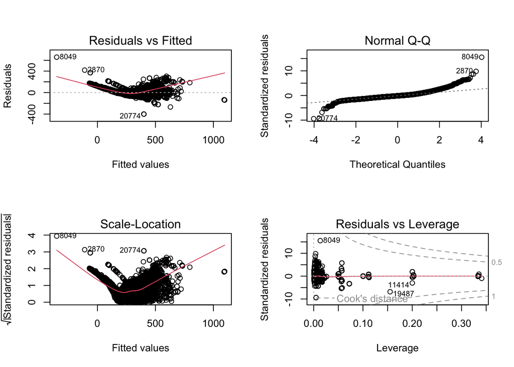

```r
par(mfrow=c(2,2))
plot(emissions.model.3)
```

Looking at the plots above, particularly the Residuals vs Fitted and the Scale-Location plots, we can see that linearity appears to be violated. Due to the parabola shape of the data, it is possible that quadratic regression could be a better fit for this data.

To see if a quadratic term could improve this model, we will add single squared regression term to the predictor variables.

```r
nonelectric$RND_ADJ_FE_2 = nonelectric$RND_ADJ_FE^2
```

```r
set.seed(101)

training.samples = nonelectric$CO2..g.mi. %>%
  createDataPartition(p = 0.8, list = FALSE)

training.data = nonelectric[training.samples,]
testing.data = nonelectric[-training.samples, ]
```

*Emissions Model 4: Quadratic Regression Model*

```r
emissions.model.4 = lm(CO2..g.mi. ~ Model.Year.Cat + Test.Veh.Displacement..L. + Vehicle.Type + Rated.Horsepower + X..of.Cylinders.and.Rotors + Tested.Transmission.Type + X..of.Gears + Drive.System.Description + Equivalent.Test.Weight..lbs.. + Axle.Ratio + N.V.Ratio + Test.Fuel.Type.Description + THC..g.mi. + RND_ADJ_FE + Target.Coef.A..lbf. + Target.Coef.B..lbf.mph. + Target.Coef.C..lbf.mph..2. + Set.Coef.A..lbf. + Set.Coef.B..lbf.mph. + RND_ADJ_FE_2, data = training.data)
```

```r
summary(emissions.model.4)
```

```
##
## Call:
## lm(formula = CO2..g.mi. ~ Model.Year.Cat + Test.Veh.Displacement..L. +
##     Vehicle.Type + Rated.Horsepower + X..of.Cylinders.and.Rotors +
##     Tested.Transmission.Type + X..of.Gears + Drive.System.Description +
##     Equivalent.Test.Weight..lbs.. + Axle.Ratio + N.V.Ratio +
##     Test.Fuel.Type.Description + THC..g.mi. + RND_ADJ_FE + Target.Coef.A..lbf. +
##     Target.Coef.B..lbf.mph. + Target.Coef.C..lbf.mph..2. + Set.Coef.A..lbf. +
##     Set.Coef.B..lbf.mph. + RND_ADJ_FE_2, data = training.data)
##
## Residuals:
##     Min      1Q  Median      3Q     Max
## -641.54  -11.26   -1.61   10.92  244.82
##
## Coefficients:
##                                                                                             Estimate
## (Intercept)                                                                                8.568e+02
## Model.Year.Cat2019                                                                         5.260e-01
## Model.Year.Cat2020                                                                         1.715e+00
## Model.Year.Cat2021                                                                         7.048e-01
## Model.Year.Cat2022                                                                         1.855e+00
## Test.Veh.Displacement..L.                                                                  3.074e+00
## Vehicle.TypeCar                                                                           -6.975e-01
## Vehicle.TypeTruck                                                                         -5.158e+00
## Rated.Horsepower                                                                           3.217e-02
## X..of.Cylinders.and.Rotors                                                                 1.751e+00
## Tested.Transmission.TypeAutomated Manual- Selectable (e.g. Automated Manual with paddles)  4.313e+00
## Tested.Transmission.TypeAutomatic                                                          7.911e+00
## Tested.Transmission.TypeContinuously Variable                                              1.028e+01
## Tested.Transmission.TypeManual                                                             4.536e+00
## Tested.Transmission.TypeOther                                                              1.105e+01
## Tested.Transmission.TypeSelectable Continuously Variable (e.g. CVT with paddles)           1.243e+01
## Tested.Transmission.TypeSemi-Automatic                                                     9.087e+00
## X..of.Gears                                                                               -7.366e-01
## Drive.System.Description2-Wheel Drive, Rear                                               -8.034e+00
## Drive.System.Description4-Wheel Drive                                                     -7.545e+00
## Drive.System.DescriptionAll Wheel Drive                                                   -7.647e+00
## Drive.System.DescriptionPart-time 4-Wheel Drive                                           -1.764e+01
## Equivalent.Test.Weight..lbs..                                                             -4.306e-03
## Axle.Ratio                                                                                -1.095e+00
```

[output cut: 186 more lines]

```
## Test.Fuel.Type.DescriptionTier 3 E10 Regular Gasoline (9 RVP @Low Alt.)                   ***
## THC..g.mi.                                                                                ***
## RND_ADJ_FE                                                                                ***
## Target.Coef.A..lbf.                                                                       ***
## Target.Coef.B..lbf.mph.                                                                   ***
## Target.Coef.C..lbf.mph..2.                                                                ***
## Set.Coef.A..lbf.                                                                          ***
## Set.Coef.B..lbf.mph.
## RND_ADJ_FE_2                                                                              ***
## ---
## Signif. codes:  0 '***' 0.001 '**' 0.01 '*' 0.05 '.' 0.1 ' ' 1
##
## Residual standard error: 25.49 on 17195 degrees of freedom
## Multiple R-squared:  0.9479, Adjusted R-squared:  0.9478
## F-statistic:  7454 on 42 and 17195 DF,  p-value: < 2.2e-16
```

```r
pred4 = emissions.model.4 %>% predict(testing.data)
p4 = data.frame(
  RMSE = RMSE(pred4, testing.data$CO2..g.mi.),
  R2 = R2(pred4, testing.data$CO2..g.mi.)
)
```

```r
combined = rbind(p1, p2, p3, p4)

combined = cbind(combined, c(summary(emissions.model)$fstatistic[1], summary(emissions.model.2)$fstatistic[1], summary(emissions.model.3)$fstatistic[1], summary(emissions.model.4)$fstatistic[1]))

combined=cbind(combined, c(summary(emissions.model)$adj.r.squared, summary(emissions.model.2)$adj.r.squared, summary(emissions.model.3)$adj.r.squared, summary(emissions.model.4)$adj.r.squared))

combined=cbind(combined,c(summary(emissions.model)$sigma,summary(emissions.model.2)$sigma, summary(emissions.model.3)$sigma, summary(emissions.model.4)$sigma))

combined=cbind(combined, c("Model 1", "Model 2", "Model 3", "Model 4"))
colnames(combined)[c(3,4,5,6)] = c("F-Statistic", "Adj R2", "RSE", "Model Name")
```

```r
library(kableExtra)
combined %>%
  kbl() %>%
  kable_classic(full_width = F, html_font = "Cambria")
```

| RMSE | R2 | F-Statistic | Adj R2 | RSE | Model Name |
| --- | --- | --- | --- | --- | --- |
| 67.19786 | 0.6954633 | 2002.677 | 0.8555428 | 42.40103 | Model 1 |
| 67.93032 | 0.6903372 | 2144.816 | 0.8539192 | 42.63865 | Model 2 |
| 67.94107 | 0.6903654 | 2449.245 | 0.8534456 | 42.70771 | Model 3 |
| 390.62920 | 0.0712754 | 7453.846 | 0.9478072 | 25.48660 | Model 4 |

*Results*

Therefore, the best model is still the multiple linear regression model of Model 3.

```r
summary(emissions.model.3)
```

```
##
## Call:
## lm(formula = CO2..g.mi. ~ Model.Year.Cat + Test.Veh.Displacement..L. +
##     Vehicle.Type + Rated.Horsepower + X..of.Cylinders.and.Rotors +
##     Tested.Transmission.Type + X..of.Gears + Drive.System.Description +
##     Equivalent.Test.Weight..lbs.. + Axle.Ratio + N.V.Ratio +
##     Test.Fuel.Type.Description + THC..g.mi. + RND_ADJ_FE + Target.Coef.A..lbf. +
##     Target.Coef.B..lbf.mph. + Target.Coef.C..lbf.mph..2. + Set.Coef.A..lbf. +
##     Set.Coef.B..lbf.mph., data = training.data)
##
## Residuals:
##     Min      1Q  Median      3Q     Max
## -401.15  -23.83   -5.08   15.86  658.98
##
## Coefficients:
##                                                                                             Estimate
## (Intercept)                                                                                5.454e+02
## Model.Year.Cat2019                                                                         1.585e+00
## Model.Year.Cat2020                                                                         3.593e+00
## Model.Year.Cat2021                                                                         3.038e+00
## Model.Year.Cat2022                                                                         4.955e+00
## Test.Veh.Displacement..L.                                                                  6.016e+00
## Vehicle.TypeCar                                                                            6.217e+00
## Vehicle.TypeTruck                                                                         -6.496e+00
## Rated.Horsepower                                                                           3.818e-02
## X..of.Cylinders.and.Rotors                                                                 5.865e+00
## Tested.Transmission.TypeAutomated Manual- Selectable (e.g. Automated Manual with paddles) -5.770e+00
## Tested.Transmission.TypeAutomatic                                                         -3.771e+00
## Tested.Transmission.TypeContinuously Variable                                              1.415e+01
## Tested.Transmission.TypeManual                                                            -9.368e+00
## Tested.Transmission.TypeOther                                                             -9.975e+00
## Tested.Transmission.TypeSelectable Continuously Variable (e.g. CVT with paddles)           8.109e+00
## Tested.Transmission.TypeSemi-Automatic                                                    -2.917e+00
## X..of.Gears                                                                               -1.510e+00
## Drive.System.Description2-Wheel Drive, Rear                                               -6.839e+00
## Drive.System.Description4-Wheel Drive                                                      5.472e-01
## Drive.System.DescriptionAll Wheel Drive                                                   -3.482e+00
## Drive.System.DescriptionPart-time 4-Wheel Drive                                           -1.955e+01
## Equivalent.Test.Weight..lbs..                                                             -6.083e-03
## Axle.Ratio                                                                                -6.750e+00
```

[output cut: 181 more lines]

```
## Test.Fuel.Type.DescriptionTier 3 E10 Premium Gasoline (9 RVP @Low Alt.)                   **
## Test.Fuel.Type.DescriptionTier 3 E10 Regular Gasoline (9 RVP @Low Alt.)                   ***
## THC..g.mi.                                                                                ***
## RND_ADJ_FE                                                                                ***
## Target.Coef.A..lbf.                                                                       ***
## Target.Coef.B..lbf.mph.                                                                   ***
## Target.Coef.C..lbf.mph..2.                                                                ***
## Set.Coef.A..lbf.                                                                          ***
## Set.Coef.B..lbf.mph.                                                                      ***
## ---
## Signif. codes:  0 '***' 0.001 '**' 0.01 '*' 0.05 '.' 0.1 ' ' 1
##
## Residual standard error: 42.71 on 17196 degrees of freedom
## Multiple R-squared:  0.8538, Adjusted R-squared:  0.8534
## F-statistic:  2449 on 41 and 17196 DF,  p-value: < 2.2e-16
```

Looking again at the summary of Emissions Model 3, we can see that the top 3 predictors that hold the most weight in predicting a car’s $CO_2$ based on respective t-values are:

1. Miles per Gallon (RND_ADJ_FE): -174.25

As the number of miles per gallon a car is able to achieve increases, its $CO_2$ emissions go down.

2. Total hydrocarbon emissions (THC..g.mi.): 35.12
3. Electric Dynamometer Coefficient/mph (Target.Coef.B..lbf.mph.): 21.90

(This is the measure of force, speed, and power required to operate the car being measured)

As the total hydrocarbon emissions and the electric dynamometer coefficient increase, the $CO_2$ emissions produced by a car will also increase.